# Practical Machine Learning Project

Amar Kumar

Monday, September 15, 2014

### Goals:

This project is to predict the manner in which the subjects did the exercise.

### Introduction:

We will use the weight lifting dataset (source: http://groupware.les.inf.puc-rio.br/har) to investigate “how (well)” an activity was performed by the wearer. The dataset contains various predictors data collected through various sensors while doing Weight Lifting Exercises. The classe outcome in the traing data set can be used as an outcome of all other predictor variables.

### Overview

I started with random forest algorithm thinking that I would change the algorithm in case the accuracy rate is not acceptable. However, fortunately or unfortunately, the random forest algorithm provide me excellent prediction and I need not test any other model for this project. My intial choice for random forest was due to the following reasons: * Random forests does not overfit. * One can run as many trees as he wants. * It is fast.

### Download and read the data

```r
library(caret);library(randomForest);library(rattle)
setwd("C:/Amar/4R/Machine Learning")
file1<-"pml-training.csv"
file2<-"pml-testing.csv"
if ( !file.exists(file1) ) {
    fileUrl <- "https://d396qusza40orc.cloudfront.net/predmachlearn/pml-training.csv"
    download.file(fileUrl, destfile = "pml-training.csv")
}

if ( !file.exists(file2) ) {
    fileUrl <- "https://d396qusza40orc.cloudfront.net/predmachlearn/pml-testing.csv"
    download.file(fileUrl, destfile = "pml-testing.csv")
}
trainH<-read.csv("pml-training.csv")[,-c(1,2,3,4,6)]
testHQ<-read.csv("pml-testing.csv")[,-c(1,2,3,4,6)]
```

### Cleaning the Data

- I have removed the irrelevant columns such as serial number, user name, raw_timestamp_part_1 and raw_timestamp_part_2 while reading the data itself.
- When we observe the summary of the test data, we find few columns have many “NA” and “#DIV/0!” values. We have to get rid of these junk columns.
- The time stamp is in factor format. Hence we have converted the time stamp to class- “POSIXlt” “POSIXt”.
- I am also removing the new_window predictor, as it did not contribute much in the model ( as per the output of Variable importance of the model) and was creating problem in prediction due to drop of a level in the test data.

```r
#removing #NA and #Div/0! from training set

o<-apply(trainH,2,function(x){sum(is.na(x))})
trainH1<-trainH[,o==0]
p<-apply(trainH1,2,function(x){sum(x=="#DIV/0!")})
trainH2<-trainH1[,is.na(p)|!(p>0)]
trainH2$cvtd_timestamp<-as.POSIXct(strptime(trainH2$cvtd_timestamp, "%d/%m/%Y  %H:%M"))

#removing #NA and #Div/0! from test set

o<-apply(testHQ,2,function(x){sum(is.na(x))})
testHQ1<-testHQ[,o==0]
p<-apply(testHQ1,2,function(x){sum(x=="#DIV/0!")})
testHQ2<-testHQ1[,is.na(p)|!(p>0)]
testHQ2$cvtd_timestamp<-as.POSIXct(strptime(testHQ2$cvtd_timestamp, "%d/%m/%Y  %H:%M"))

# Test data set has magnet_forearm_y and magnet_forearm_z "num" type values. However the same variables are of "int" type in the training data set.
testHQ2$magnet_forearm_y<-as.numeric(testHQ2$magnet_forearm_y)
testHQ2$magnet_forearm_z<-as.numeric(testHQ2$magnet_forearm_z)
testHQ2$magnet_dumbbell_z <-as.numeric(testHQ2$magnet_dumbbell_z)
```

### Cross Validation and Modelling

I have split the traing set into training/testing sets to validate the model built. The traing set will be used to cross-validate the derived model.

```r
set.seed(123)
inTrain<-createDataPartition(trainH2$classe, p=0.7, list=F)
trainHF<-trainH2[inTrain,];testHF<-trainH2[-inTrain,]
modFit<-randomForest(classe~.,data=trainHF, ntree=60, replace=F, importance=T)
modFit
```

```
##
## Call:
##  randomForest(formula = classe ~ ., data = trainHF, ntree = 60,      replace = F, importance = T)
##                Type of random forest: classification
##                      Number of trees: 60
## No. of variables tried at each split: 7
##
##         OOB estimate of  error rate: 0.34%
## Confusion matrix:
##      A    B    C    D    E class.error
## A 3904    2    0    0    0    0.000512
## B    8 2646    4    0    0    0.004515
## C    0   10 2384    2    0    0.005008
## D    0    0   14 2236    2    0.007105
## E    0    0    0    5 2520    0.001980
```

### Analysis of the model

The expected out of sample error is 0.34% (given by “OOB estimate of error rate”)

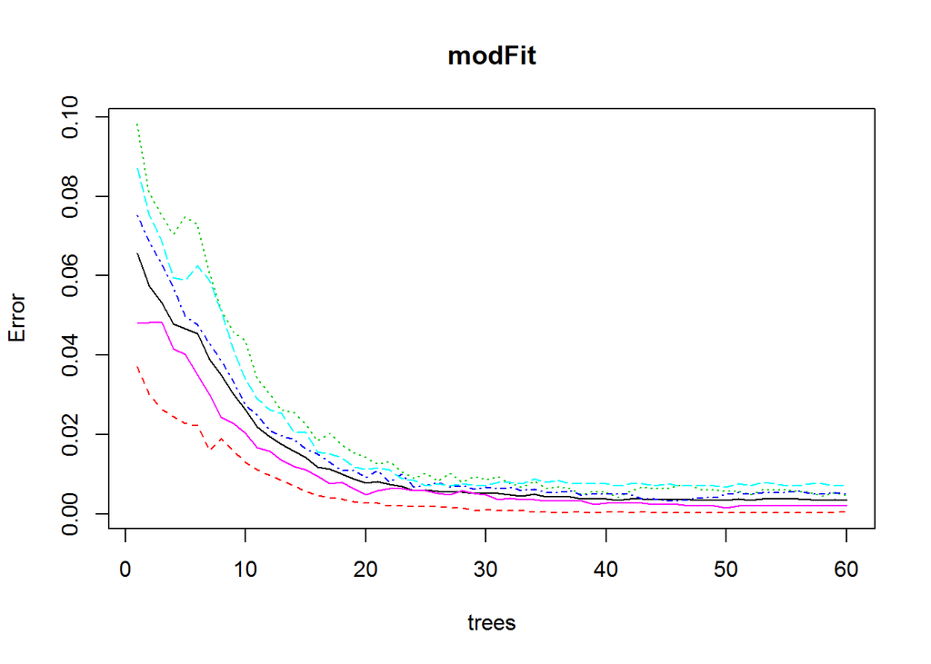

```r
plot(modFit)
```

```r
pre<-predict(modFit, testHF[,-55])
table(testHF[,55], pre)
```

```
##    pre
##        A    B    C    D    E
##   A 1673    1    0    0    0
##   B    2 1137    0    0    0
##   C    0   11 1015    0    0
##   D    0    0    2  961    1
##   E    0    0    0    0 1082
```

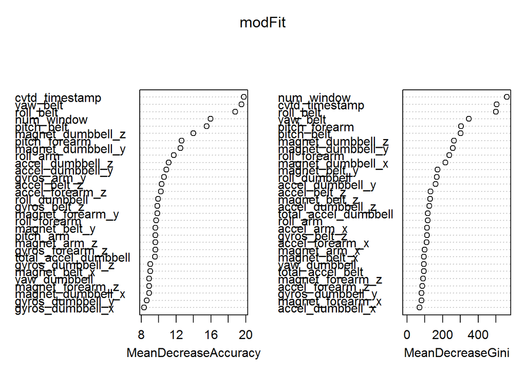

```r
# varImp(modFit)
varImpPlot(modFit)
```

- Error does not decrease beyond the number of trees =30.
- Validation test data provides a significant accurate result.
- Timestamp, yaw_belt, num_window and roll belt are top four predictors for the outcome classe.

```r
pre1<-predict(modFit, testHQ2[,-55]) # pre1
```